# Homewrk2

Yue Gu

2018.2.1

### Question 1

## (a)

The density of Cauchy (x;):
$$P(x;\theta)=\cfrac{1}{\pi[1+(x-\theta)^2]}$$
Because $x_{1},x_{2}...x_{n}$are i.i.d, log-likelihood function $l(\theta)$ equals:
$$l(\theta)=\ln(\prod_{1}^n p(x_{i};\theta))=\ln(\prod_{1}^n \cfrac{1}{\pi[1+(x_{i}-\theta)^2]})$$
$$l(\theta)=\sum_{1}^n \ln (\cfrac{1}{\pi[1+(x_{i}-\theta)^2]})$$
$$l(\theta)=-n\ln\pi-\sum_{1}^n \ln[1+(\theta-x_{i})^2]$$
$$l^{'}(\theta)=-2\sum_{1}^n \cfrac{\theta-x_{i}}{1+(\theta-x_{i})^2}$$
$$l^{''}(\theta)=-2\sum_{1}^n \cfrac{1-(\theta-x_{i})^2}{[1+(\theta-x_{i})^2]^2}$$
$$I(\theta)=n\int \cfrac{[p^{'}(x)]^2}{p(x)}=\cfrac{4n}{\pi} \int_{-\infty}^{\infty} \cfrac{x^2dx}{(1+x^2)^3}$$
We set $x=\tan(t) t\in (-\cfrac{\pi}{2},\cfrac{\pi}{2})$, then we have:
$$I(\theta)=\cfrac{4n}{\pi} \int_{-\cfrac{\pi}{2}}^{\cfrac{\pi}{2}} \cfrac{\tan^2(t)d(\tan(t))}{(1+tan^2(t))^3}$$
$$=\cfrac{4n}{\pi} \int_{-\cfrac{\pi}{2}}^{\cfrac{\pi}{2}} \cfrac{\tan^2(t)}{(\cfrac{1}{\sec^2(t)})^3}(\cfrac{1}{\sec^2(t)})dt$$
$$=\cfrac{4n}{\pi} \int_{-\cfrac{\pi}{2}}^{\cfrac{\pi}{2}} \cfrac{\sin^2(t)}{\cos^2(t)}\cos^4(t)dt$$
$$\cfrac{4n}{\pi} \int_{-\cfrac{\pi}{2}}^{\cfrac{\pi}{2}}\sin^2(t)\cos^2(t)dt$$
$$=\cfrac{4n}{\pi}*\cfrac{\pi}{8}=\cfrac{n}{2}$$

## (b)

The observed sample is X <- c(1.77, -0.23, 2.76, 3.80, 3.47, 56.75, -1.34, 4.24, -2.44, 3.29, 3.71, -2.40, 4.53, -0.07, -1.05, -13.87, -2.53, -1.75)

```r
X <- c(1.77, -0.23, 2.76, 3.80, 3.47, 56.75, -1.34, 4.24, -2.44,
3.29, 3.71, -2.40, 4.53, -0.07, -1.05, -13.87, -2.53, -1.75)
log_p <- function(theta,x) {
  -log(pi)-log(1+(theta-x)^2)
}

log_likelihood <- function(theta) {
    log_p(theta,1.77)+log_p(theta,-0.23)+log_p(theta,2.76)+log_p(theta,3.80)+log_p(theta,3.47)+log_p(theta,56.75)+log_p(theta,-1.34)+log_p(theta,4.24)+log_p(theta,-2.44)+log_p(theta,3.29)+log_p(theta,3.71)+log_p(theta,-2.40)+log_p(theta,4.53)+log_p(theta,-0.07)+log_p(theta,-1.05)+log_p(theta,-13.87)+log_p(theta,-2.53)+log_p(theta,-1.75)
}

neg_log_likelihood <- function(theta) {
    -(log_p(theta,1.77)+log_p(theta,-0.23)+log_p(theta,2.76)+log_p(theta,3.80)+log_p(theta,3.47)+log_p(theta,56.75)+log_p(theta,-1.34)+log_p(theta,4.24)+log_p(theta,-2.44)+log_p(theta,3.29)+log_p(theta,3.71)+log_p(theta,-2.40)+log_p(theta,4.53)+log_p(theta,-0.07)+log_p(theta,-1.05)+log_p(theta,-13.87)+log_p(theta,-2.53)+log_p(theta,-1.75))
}

outcome_neg_11 <- nlminb(-11,neg_log_likelihood)
theta_neg_11 <- outcome_neg_11$par
outcome_neg_1 <- nlminb(-1,neg_log_likelihood)
theta_neg_1 <- outcome_neg_1$par
outcome_0 <- nlminb(0,neg_log_likelihood)
theta_0 <- outcome_0$par
outcome_1.5 <- nlminb(1.5,neg_log_likelihood)
theta_1.5 <- outcome_1.5$par
outcome_4 <- nlminb(4,neg_log_likelihood)
theta_4<- outcome_4$par
outcome_4.7 <- nlminb(4.7,neg_log_likelihood)
theta_4.7 <- outcome_4.7$par
outcome_7 <- nlminb(7,neg_log_likelihood)
theta_7 <- outcome_7$par
outcome_8 <- nlminb(8,neg_log_likelihood)
theta_8 <- outcome_8$par
outcome_38 <- nlminb(38,neg_log_likelihood)
theta_38 <- outcome_38$par

outcome_MLE <- data.frame(c(theta_neg_11,theta_neg_1,theta_0,theta_1.5,theta_4,theta_4.7,theta_7,theta_8,theta_38))
rownames(outcome_MLE) <- c('-11','-1','0','1.5','4','4.7','7','8','38')
library(knitr)
kable(outcome_MLE, format="markdown",col.names =c('MLE'),caption="MLE for theta using the Newton-Raphson
method", padding=2)
```

|  | MLE |
| --- | --- |
| -11 | -0.5914762 |
| -1 | -0.5914735 |
| 0 | -0.5914740 |
| 1.5 | 3.0213454 |
| 4 | 3.0213454 |
| 4.7 | 3.0213455 |
| 7 | 3.0213455 |
| 8 | -0.5914708 |
| 38 | -0.5914735 |

Then we plot the curve for the log-likelihood function ranging from -100 to 100 and from -5 to 5.

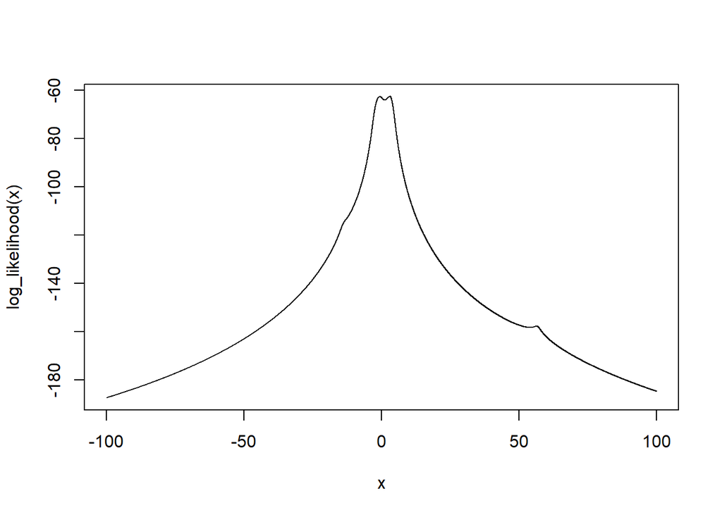

```r
curve(log_likelihood,from=-100,to=100,n=10000)
```

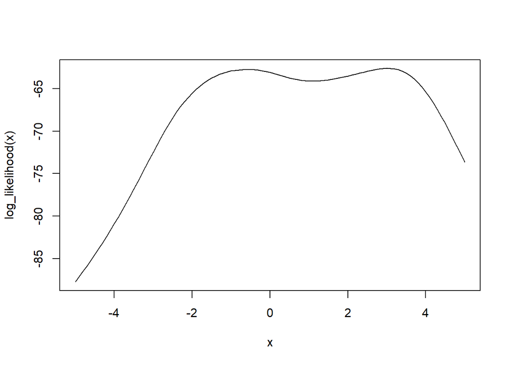

```r
curve(log_likelihood,from=-5,to=5)
```

Sample mean is a good starting point for this case.